# Analiza dokonanych rezerwacji w hotelach i resortach wypoczynkowych

Magda Pyndryk

1/15/2021

## Wprowadzenie

Obserwuje się tendencję wzrostową osób podróżujących i rezerwujących hotele. Warto więc zastanowić się nad tym, **który miesiąc w roku jest najbardziej oblegany**, czyli kiedy trzeba najwcześniej zarezerwować miejsce noclegowe.

Postawiono więc **pytanie badawcze**: W którym miesiącu warto jest dokonać rezerwacji hotelu z uwagi na najkrótszy czas pomiędzy rezerwacją a zameldowaniem? W celu odpowiedzi na pytanie badawcze, przeprowadzono **analizę wstępną** wybranych zmiennych, szukając zależności i wykrywając prawidłowości występujące pomiędzy zmiennymi. Następnie przeprowadzono **analizę zaawansowaną**, wykorzystując model regresji liniowej.

### Zbiór danych

**Zbiór danych** przyjęty do analizy, której wyniki zaprezentowano poniżej, pochodzi z kaggle.com. Zbiór zawiera informacje o rezerwacjach miejsc w hotelach oraz resortach wypoczynkowych. Szczegółowymi informacjami przechowywanymi w kolumnach są m.in. data dokonania rezerwacji, długość pobytu, liczba zameldowanych osób czy też liczba dostępnych miejsc parkingowych.

Zbiór danych (źródło): https://www.kaggle.com/jessemostipak/hotel-booking-demand

## Analiza eksploracyjna

### Załadowanie bazy danych:

```r
df <- read.csv("/Users/magdapyndryk/Desktop/hotel.csv", header = TRUE, sep=";")
df$arrival_date_month = factor(df$arrival_date_month, levels = month.name)
```

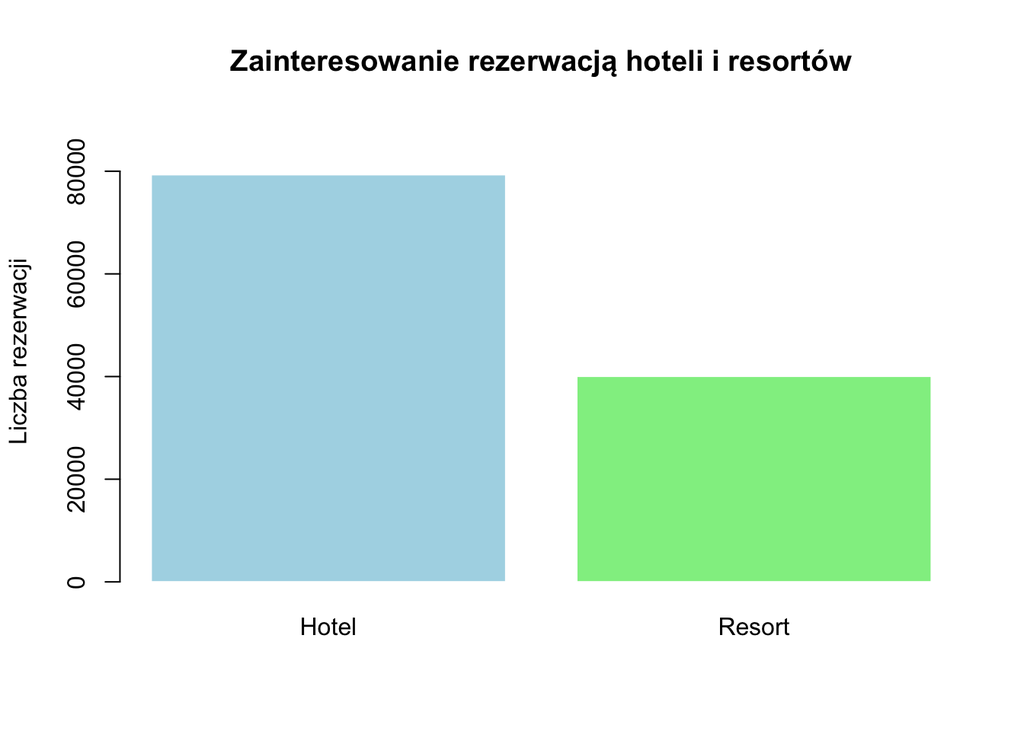

```r
library(ggplot2)
bp <- barplot(table(df$hotel), main = "Zainteresowanie rezerwacją hoteli i resortów", ylab = "Liczba rezerwacji", ylim = c(0,90000), col = c("lightblue", "lightgreen"), border = "white", names.arg = c("Hotel", "Resort"), width = 0.85)
```

Z powyższego wykresu wynika, że **większym zainteresowaniem wśród podróżnych cieszy się rezerwowanie hoteli** (zwykle umiejscowionych w obrębie miasta). Mniej osób natomiast wybiera resorty wypoczynkowe.

```r
summary(df$lead_time)
```

```
##    Min. 1st Qu.  Median    Mean 3rd Qu.    Max.
##       0      18      69     104     160     737
```

**“Lead time”** zgodnie z definicją przyjętą w hotelarstwie **oznacza czas realizacji rezerwacji**, czyli okres pomiędzy dokonaniem przez gościa rezerwacji a faktyczną datą zameldowania. W niniejszym zbiorze czas ten określony jest w godzinach. Podstawowe statystyki dotyczące tej zmiennej wraz z wynikiem zostały zaprezentowane w powyższej tabeli.

### Przedstawienie graficzne rozkładów zmiennej: arrival_date_day_of_month, lead_time, arrival_date_week_number

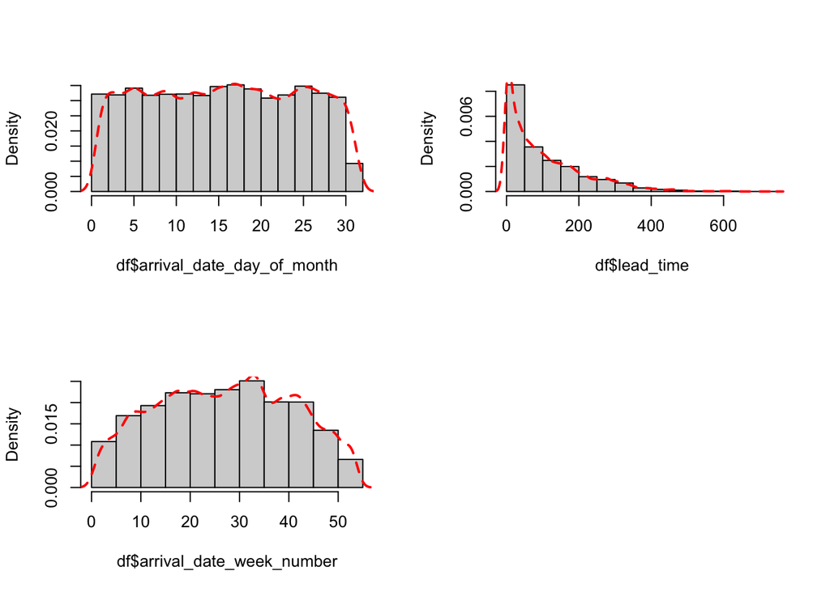

```r
library(ggplot2)
library(cowplot)

par(mfrow=c(2,2))

hist(df$arrival_date_day_of_month, main="", probability = T)
lines(density(df$arrival_date_day_of_month), lwd=2, col="red", lty=2)

hist(df$lead_time, main="", probability = T)
lines(density(df$lead_time), lwd=2, col="red", lty=2)

hist(df$arrival_date_week_number, main="", probability = T)
lines(density(df$arrival_date_week_number), lwd=2, col="red", lty=2)
```

**Histogram wizualnie reprezentuje zmienną**. W związku z tym kształt histogramu łatwo pozwala zobaczyć, gdzie znajduje się stosunkowo duża ilość danych a gdzie jest ich mało. Innymi słowy można zobaczyć, gdzie znajduje się środek wystąpienia największej grupy danych, jak blisko tego środka znajdują się dane oraz gdzie można znaleźć możliwe wartości odstające.

W związku z powyższym, histogramy bardzo dobrze sprawdzają się w procesie wstępnej analizy danych.

Korzystając ze zbioru danych dotyczącego branży hotelarskiej, **wyświetlono trzy histogramy**. Pierwszy z nich, znajdujący się w lewym górnym rogu dotyczy zmiennej arrival_date_day_of_month, czyli dni miesiąca, w których goście przyjechali do hotelu/resortu wypoczynkowego. Można zauważyć, że **najwięcej gości przyjechało do wcześniej zarezerwowanego miejsca w połowie miesiąca, najmniej zaś na końcu**. Kolejny histogram, znajdujący się obok dotychczas opisanego, charakteryzuje zmienną lead_time, czyli okres pomiędzy dokonaniem przez gościa rezerwacji a faktyczną datą zameldowania. Można zauważyć tendencję spadkową takiego zjawiska. Oznacza to, że **im więcej czasu mijało od daty rezerwacji do daty zameldowania, tym mniej osób decydowało się na rezerwację**. W krótkim czasie przed zameldowaniem, było najwięcej rezerwacji. Ostatni histogram koncentruje się na pokazaniu prawidłowości zachodzących wśród danych dla zmiennej arrival_date_week_number. Zmienna ta zawiera informacje o tym, w którym tygodniu całego roku dokonano najwięcej rezerwacji. Wynika z niego, że **najmniej rezerwacji dokonywano w początkowych i końcowych tygodniach roku**, czyli takich, które przypadają w okresie zimowym. Podczas wakacji, czyli w środku roku wystąpiło najwięcej rezerwacji.

### Badanie zależności pomiędzy zmiennymi: arrival_date_week_number a lead_time

```r
library(corrplot)
cor(df$arrival_date_week_number, df$lead_time, method = "pearson")
```

```
## [1] 0.1268708
```

Chcąc zbadać zależność pomiędzy zmiennymi, **warto skorzystać z metod korelacji**. W tym celu skorzystano z jednej z miar badania zależności statystycznej pomiędzy wskazanymi zmiennymi - **korelacji Pearsona**. Uzyskany wynik nie wskazuje, że pomiędzy zmiennymi wybranymi do badania występuje wysoka korelacja. Jest ona niewielka, gdyż osiąga 0.1268708. Otrzymany rezultat świadczy jednak o tym, że **występuje korelacja dodatnia**.

### Częstotliwość rezerwacji pobytu w ciągu tygodnia. Analiza na przestrzeni 3 lat.

```r
library(tidyverse)
```

```r
library(dplyr)
library(dygraphs)
library(sp)
library(htmltools)

df %>%
  group_by(arrival_date_year, arrival_date_month) %>%
  summarise(stays_in_week_nights=sum(stays_in_week_nights)) %>%
  ungroup() %>%
  transmute(stays_in_week_nights) %>%
  ts(start=c(2015,7), end=c(2017,8), frequency = 12) -> time_ts
df %>%
  group_by(arrival_date_year, arrival_date_month) %>%
  filter(hotel=="City Hotel") %>%
  summarise(stays_in_week_nights=sum(stays_in_week_nights)) %>%
  ungroup() %>%
  transmute(stays_in_week_nights) %>%
  ts(start=c(2015,7), end=c(2017,8), frequency = 12) -> time_hotel
time_hotel %>%
  dygraph(width=800,height=200,group="fourstations",main="Hotel") %>%
  dyOptions(colors ='Red') %>%
  dyAxis('x', 'Rok') %>%
  dyAxis('y', 'Zameldowanie w tyg.')
```

[interactive chart not shown]

```r
df %>%
  group_by(arrival_date_year, arrival_date_month) %>%
  filter(hotel=="Resort Hotel") %>%
  summarise(stays_in_week_nights=sum(stays_in_week_nights)) %>%
  ungroup() %>%
  transmute(stays_in_week_nights) %>%
  ts(start=c(2015,7), end=c(2017,8), frequency = 12) -> time_resort
```

```r
time_resort %>%
  dygraph(width=800,height=200,group="fourstations",main="Resort wypoczynkowy") %>%
  dyOptions(colors ='Green') %>%
  dyAxis('x', 'Rok') %>%
  dyAxis('y', 'Zameldowanie w tyg.')
```

[interactive chart not shown]

Dokonano **analizy częstotliwości rezerwacji** miejsca noclegowego w hotelach i osobno w resortach wypoczynkowych. Wykresy prezentują sumę ilości pobytu w hotelach i resortach wypoczynkowych w każdym miesiącu na przestrzeni trzech lat (analiza uwzględnia 2015, 2016 i 2017 rok).

Trudno jest ocenić, które miejsce noclegowe “wypadło” w tym zestawieniu lepiej, gdyż oba odnotowały fluktuacje - wzrosty i spadki zainteresowania wśród gości. Warto jednak podjąć próbę interpretacji wykresów. **Najmniejszym zainteresowaniem rezerwacji hoteli okazał się miesiąc wrzesień 2015 roku.** W tym terminie pzostało dokonanych tylko 2647 rezerwacji. Od maja 2016 roku, nie odnotowano spadku rezerwacji poniżej 5000.

## Regresja liniowa

```r
model <- lm(df$arrival_date_week_number ~ df$lead_time, data = df)
model
```

```
##
## Call:
## lm(formula = df$arrival_date_week_number ~ df$lead_time, data = df)
##
## Coefficients:
##  (Intercept)  df$lead_time
##     25.48514       0.01615
```

Beta 0 wynosi 25,48. Można to interpretować jako przewidywaną jednostkę w odniesieniu do zakwaterowania w konkretnym tygodniu roku zakładając, że istnieje “lead time” praktycznie zerowy (czyli można zameldować się przychodząc do hotelu). Innymi słowy, **zakładając zerowy “lead time” najbezpieczniej będzie dokonać rezerwacji w 25 tygodniu roku.**

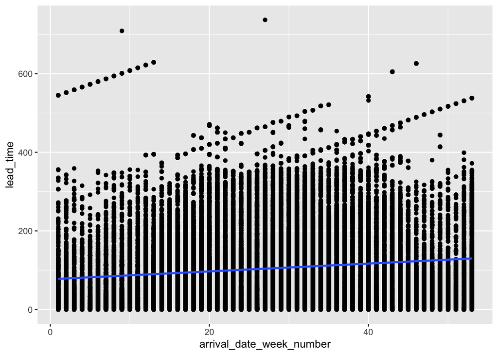

```r
library(ggplot2)
ggplot(df, aes(arrival_date_week_number, lead_time)) +
  geom_point() +
  stat_smooth(method = lm)
```

```r
summary(model)
```

```
##
## Call:
## lm(formula = df$arrival_date_week_number ~ df$lead_time, data = df)
##
## Residuals:
##     Min      1Q  Median      3Q     Max
## -33.288 -10.986  -0.202  10.425  27.515
##
## Coefficients:
##               Estimate Std. Error t value Pr(>|t|)
## (Intercept)  2.549e+01  5.450e-02  467.59   <2e-16 ***
## df$lead_time 1.615e-02  3.655e-04   44.19   <2e-16 ***
## ---
## Signif. codes:  0 '***' 0.001 '**' 0.01 '*' 0.05 '.' 0.1 ' ' 1
##
## Residual standard error: 13.5 on 119388 degrees of freedom
## Multiple R-squared:  0.0161, Adjusted R-squared:  0.01609
## F-statistic:  1953 on 1 and 119388 DF,  p-value: < 2.2e-16
```

#### Sumaryczne podsumowanie modelu zawiera 6 informacji:

**Call** - pokazuje wywołanie funkcji użytej do obliczenia modelu regresji. **Residuals** - zapewniają szybki podgląd rozkładu reszt, które z definicji mają średnią zerową. Dlatego też mediana nie powinna być daleka od zera. Natomiast minimum i maksimum powinny mieć mniej więcej równą wartość bezwzględną. **Coefficients** - pokazuje współczynniki regresji beta i ich istotność statystyczną. Zmienne predykcyjne, które są istotnie związane ze zmienną wynikową są oznaczone gwiazdkami. **Residual standard error (RSE), R-squared (R^2)** oraz **F-statistic** są miarami używanymi do sprawdzenia, jak dobrze model dopasowany jest do danych.

Tabela współczynników w podsumowaniu statystycznym modelu przedstawia oszacowania współczynników beta oraz błędy standardowe (SE), które określają dokładność współczynników beta. Dla danego współczynnika beta, SE odzwierciedla zmiany współczynnika przy powtarzanym próbkowaniu. Można go użyć do obliczenia przedziałów ufności i statystyki t. Statystyka ta i związana z nią wartość p, która definiuje istotność statystyczną współczynników beta.

Dla danego predyktora, statystyka t (i związana z nią wartość p) sprawdza, czy istnieje statystycznie istotna zależność między danym predyktorem a zmienną wynikową, to znaczy, czy współczynnik beta predyktora jest znacząco różny od zera.

#### Hipotezy statystyczne są następujące:

**Hipoteza zerowa (H0)**: współczynniki są równe zero (tj. Brak związku między x i y) **Hipoteza alternatywna (H1)**: współczynniki nie są równe zeru (tj. Istnieje pewna zależność między x i y). Statystyka t mierzy liczbę odchyleń standardowych, których wartość b jest oddalona od 0. Zatem duża statystyka t da małą wartość p.

Im wyższa statystyka t (i niższa wartość p), tym bardziej istotny jest predyktor. Symbole po prawej stronie wizualnie określają poziom istotności. Linia pod tabelą przedstawia definicje tych symboli. Im więcej gwiazd obok wartości p zmiennej, tym bardziej znacząca jest zmienna.

Statystycznie istotny współczynnik wskazuje, że istnieje związek między predyktorem (x) a zmienną wyniku (y).

Dokonując analizy dla danych z branży hotelarskiej, zarówno wartości p dla punktu przecięcia, jak i zmiennej predykcyjnej są bardzo istotne, więc możemy odrzucić hipotezę zerową i zaakceptować hipotezę alternatywną, co oznacza, że istnieje istotny związek między predyktorem a zmiennymi wyniku. Innymi słowy, **istnieje znaczący związek pomiędzy okresem “lead time” a zameldowaniem w konkretnym tygodniu roku.**

```r
confint(model)
```

```
##                    2.5 %      97.5 %
## (Intercept)  25.37831481 25.59196414
## df$lead_time  0.01543605  0.01686874
```

Statystyka t jest bardzo użytecznym przewodnikiem, jeśli chodzi o uwzględnianie predyktora w modelu. Wysokie statystyki t (które idą w parze z niskimi wartościami p bliskimi 0) wskazują, że predyktor powinien zostać zachowany w modelu, podczas gdy bardzo niskie statystyki t wskazują, że predyktor może zostać odrzucony.

## Zakończenie

Na początku raportu postawiono pytanie badawcze: **W którym miesiącu warto jest dokonać rezerwacji hotelu z uwagi na najkrótszy czas pomiędzy rezerwacją a zameldowaniem?** Podjęto próby wskazania zależności zachodzących pomiędzy wybranymi zmiennymi, które mogłby wnieść kluczowe informacje. Takimi zmiennymi były: lead_time, arrive_date_week_number, stays_in week_nights. W wyniku przeprowadzenia analizy regresji liniowej, ustalono, że z uwagi na najkrótszy czas pomiędzy rezerwacją a zameldowaniem **należy dokonać rezerwacji w 25 tygodniu roku, czyli w czerwcu.**

Praca z wybranym zbiorem danych okazywała się być w pewnych momentach kłopotliwa, co najpewniej można wyjaśnić strukturą zbioru. Tematyka zbioru jest natomiast interesująca i warto będzie uzupełnić zbiór o większą liczbę danych, co pozwoli zbudować lepsze i dokładniejsze modele i przeprowadzać bardziej zaawansowane analizy. Zarazem będzie także dobrym treningiem posługiwania się językiem R.